# DRAFT State and Township PIN allocations

[Myanmar Food Security Cluster](https://github.com/food-security-cluster-myanmar)

20/09/2022

## Introduction

This document outlines a proposal to calculate the Food Security Cluster PIN based on a combination of REACH MSNA data and FAO/WFP survey Round 3.

It is currently unclear if the fourth round of results from FAO/WFP will be ready in time for the rest of the 2023 planning exercises. Though, it should also be mentioned that a cursory inspection of the various datasets shows the MSNA to be very well conducted and a more than able replacement for the FAO/WFP survey, should it not be finished in time.

I would also encourage any and all comments from all concerned parties.

## Data and references

### References for this report

- ACLED, (2022). ACLED data for Myanmar (2010-2022). Retrieved from https://acleddata.com on 2022-06-06.
- International Food Policy Research Institute (2022). Myanmar Household Welfare Survey (MHWS), Round 1. Harvard Dataverse, doi: 10.7910/DVN/1R3F3U,. Retrieved from https://doi.org/10.7910/DVN/1R3F3U on 2022-09-01.
- FAO and WFP (2022). Food Security Monitoring Survey Round 3. FAO and WFP.
- Food Security Cluster Myanmar (2022). Township Prioritisation. https://food-security-cluster-myanmar.github.io/mmr_township_prioritisation/.
- Food Security Cluster, Myanmar (2022). Understanding Conflict Dynamics in Myanmar through Conflict and Incident Data: A Food Security Perspective. https://food-security-cluster-myanmar.github.io/exploratory-data-analysis-acled-fsc/.
- HARP-F and MIMU (2018). Vulnerability in Myanmar: A Secondary Data Review of Needs, Coverage and Gaps. http://themimu.info/vulnerability-in-myanmar.
- REACH (2022). Myanmar Multi-sector Needs Assessment. REACH.

Additionally, the draft township-level PINs have been read into a simplet dataset [here](https://github.com/food-security-cluster-myanmar/allocation_proposal/raw/main/data/draft_pin_dataset.xlsx) for easy comparison and comsumption.

## State and Region PINs

```
## [1] 37823251
```

Using the food consumption scores from the MSNA and the reduced coping strategies index from the FAO/WFP Survey Round 3, it has been possible to replicate the CARI methodology used to calculate the 2022 PIN.

Below is an explanatory chart where how each of the food consumption and coping strategies indicators relate to the 4 CARI domains.

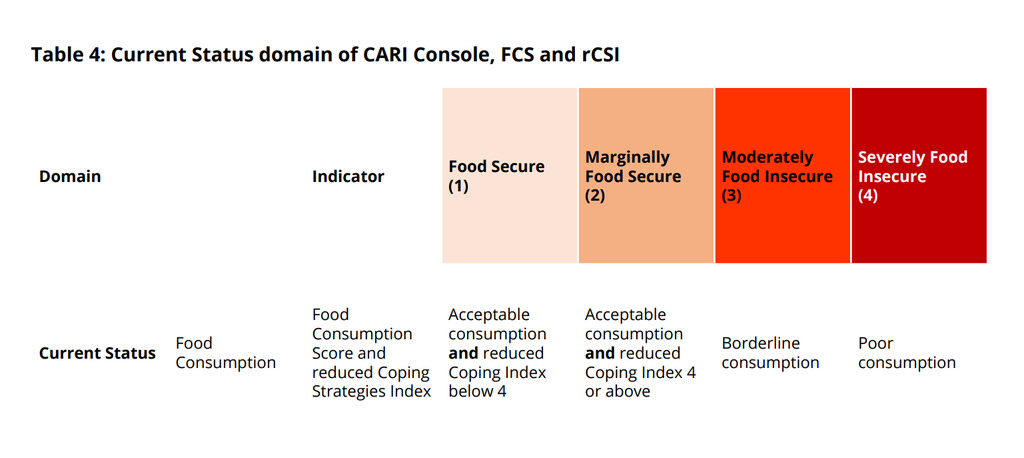

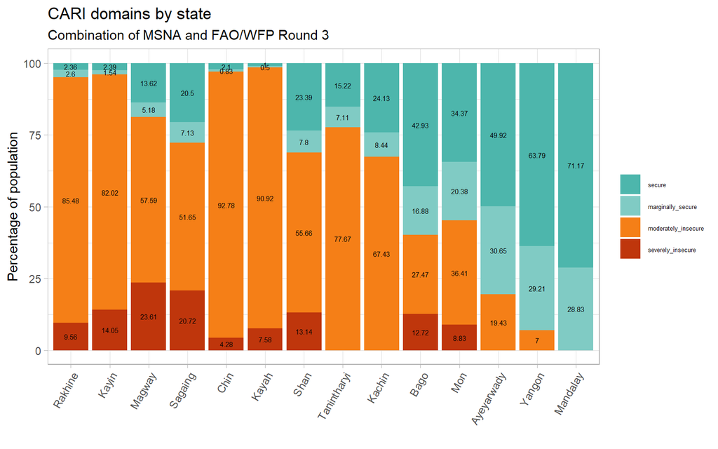

Presented as a table:

PIN and CARI domain breakdown by state

| state | population | PIN | %_PIN | %_secure | %_marginally secure | %_moderately insecure | %_severely insecure |
| --- | --- | --- | --- | --- | --- | --- | --- |
| Kayah | 1,843,383 | 1,815,732 | 4.80 | 1.00 | 0.50 | 90.92 | 7.58 |
| Chin | 1,875,442 | 1,820,304 | 4.81 | 2.10 | 0.83 | 92.78 | 4.28 |
| Kayin | 4,477,551 | 4,301,583 | 11.37 | 2.39 | 1.54 | 82.02 | 14.05 |
| Rakhine | 10,964,121 | 10,420,301 | 27.55 | 2.36 | 2.60 | 85.48 | 9.56 |
| Magway | 5,754,561 | 4,672,703 | 12.35 | 13.62 | 5.18 | 57.59 | 23.61 |
| Tanintharyi | 1,025,883 | 796,803 | 2.11 | 15.22 | 7.11 | 77.67 | 0.00 |
| Sagaing | 6,406,424 | 4,636,329 | 12.26 | 20.50 | 7.13 | 51.65 | 20.72 |
| Shan | 9,040,591 | 6,219,927 | 16.44 | 23.39 | 7.80 | 55.66 | 13.14 |
| Kachin | 1,127,402 | 760,207 | 2.01 | 24.13 | 8.44 | 67.43 | 0.00 |
| Mon | 790,785 | 357,751 | 0.95 | 34.37 | 20.38 | 36.41 | 8.83 |
| Bago | 3,296,717 | 1,324,950 | 3.50 | 42.93 | 16.88 | 27.47 | 12.72 |
| Ayeyarwady | 2,676,913 | 520,124 | 1.38 | 49.92 | 30.65 | 19.43 | 0.00 |
| Yangon | 2,521,962 | 176,537 | 0.47 | 63.79 | 29.21 | 7.00 | 0.00 |
| Mandalay | 1,624,314 | 0 | 0.00 | 71.17 | 28.83 | 0.00 | 0.00 |
| Nay Pyi Taw |  |  |  | 0.00 | 0.00 | 0.00 | 0.00 |

80% of the PIN comes from Rakhine, Kayin, Magway, Sagaing and Shan. There areas are also where the majority of the population that is severely-food insecure is located.

### Limitations of the combined approach

- Some amount of data manipulation is necessary is make use of the FCS scores from the MSNA and the RCSI from the FAO/WFP survey. Download the code for this document to review the exact calculation.
- It is encouraging to see that in Yangon – and the other urban areas – the caseload is very low. This aligns with our commonsensical understanding of the response.
- Whilst the draft PIN has been developed, each of the states and regions and townships that will be mentioned below but effective programme designs have yet to be developed to address the both acute and chronic food insecurity.
- And of course the data is a bit older than FAO/WFP round 4, which is ongoing now. The MSNA was collected in August 2022 and is definitely still valid. The coping strategies indicators did come from the round 3 survey, which was conducted in April 2022.

Finally, here is the state-level PIN broken down by moderately and severely food insecure.

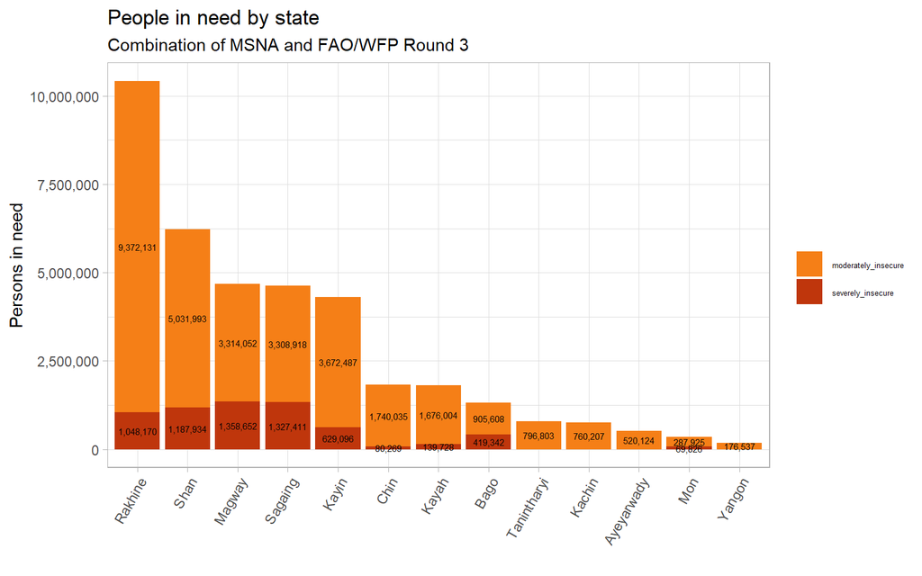

## Township PINs

This section seeks to provide specific township PINs. To do this, we make use of the state/region PINs in the section above and divide up this state-level PIN across all the townships in that state.

For reference, township-level prioritisation scores related to conflict (2022) and pre-existing vulnerability (2019) were developed in the food security cluster’s paper on [Township Prioritisation](https://food-security-cluster-myanmar.github.io/mmr_township_prioritisation/); please see there for more details.

But in brief, the conflict score is a weighted average of the following indicators:

- Number of IDPs
- Number of conflict fatalities
- Number of Battles
- Number of incidents of explosions and remote violence
- Number of incidents of violence against civilians
- Number of strategic developments (includes arrests)
- Number of non-peaceful protests and riots

And the multi-dimensional vulnerability score is an average of the following indicators, updated in 2019:

- % of population without formal identification documents
- % of population without a middle school education
- % of females who were illiterate
- % of households with bamboo or thatched roofs
- % of households with safe sanitation
- % of households with access to electricity
- % of workers who are unpaid family workers
- The child dependency ratio

The caseload for each township would be either the number of persons affected by conflict or the number of persons who had pre-exisiting multi-dimensional vulnerability, depending on which figure is higher. These township caseloads were then used to determine each townships share of the state PIN.

For instance, if township A had 20% of the caseload of the state, it should also be allocated 20% of the PIN.

For review and validation, the remaining sections of this document break down the township-level PIN by state. It would be useful to speak to your field colleagues to see if the model developed is a fair approximation of needs. Preliminary validation has already been carried out with some food security partners to some encouraging results.

In the tables below, higher conflict scores are worse, with the highest possible conflict score being `100`.

### Ayeyarwady

Proposed PIN breakdown by township

| township | population | conflict score | conflict affected | vulnerability score | pre-ex. vulnerable | moderately insecure | severely insecure | PIN | %_PIN |
| --- | --- | --- | --- | --- | --- | --- | --- | --- | --- |
| Labutta | 315,123 | 2.10 | 6,610 | 59.49 | 187,477 | 26,509 | 0 | 33,791 | 6.50 |
| Bogale | 322,568 | 2.47 | 7,982 | 55.81 | 180,038 | 27,135 | 0 | 32,450 | 6.24 |
| Mawlamyinegyun | 311,246 | 2.89 | 8,999 | 54.64 | 170,060 | 26,183 | 0 | 30,652 | 5.89 |
| Wakema | 289,019 | 2.50 | 7,233 | 57.15 | 165,180 | 24,313 | 0 | 29,772 | 5.72 |
| Pyapon | 314,027 | 5.93 | 18,620 | 50.90 | 159,851 | 26,417 | 0 | 28,812 | 5.54 |
| Maubin | 313,998 | 8.12 | 25,486 | 48.95 | 153,699 | 26,414 | 0 | 27,703 | 5.33 |
| Myaungmya | 298,547 | 4.78 | 14,282 | 51.13 | 152,636 | 25,114 | 0 | 27,511 | 5.29 |
| Ngapudaw | 324,381 | 1.97 | 6,402 | 46.25 | 150,016 | 27,288 | 0 | 27,039 | 5.20 |
| Pantanaw | 264,516 | 1.60 | 4,245 | 50.68 | 134,059 | 22,252 | 0 | 24,163 | 4.65 |
| Hinthada | 338,333 | 2.85 | 9,643 | 37.24 | 126,008 | 28,461 | 0 | 22,712 | 4.37 |
| Pathein | 380,870 | 25.65 | 97,709 | 29.39 | 111,924 | 32,040 | 0 | 20,173 | 3.88 |
| Dedaye | 202,865 | 1.56 | 3,172 | 51.50 | 104,477 | 17,065 | 0 | 18,831 | 3.62 |
| Einme | 194,043 | 1.21 | 2,349 | 53.42 | 103,661 | 16,323 | 0 | 18,684 | 3.59 |
| Kyonpyaw | 235,656 | 2.52 | 5,933 | 42.20 | 99,441 | 19,824 | 0 | 17,923 | 3.45 |
| Kyaiklat | 193,282 | 1.85 | 3,567 | 51.31 | 99,163 | 16,259 | 0 | 17,873 | 3.44 |
| Nyaungdon | 215,841 | 2.80 | 6,054 | 45.88 | 99,020 | 18,157 | 0 | 17,847 | 3.43 |
| Myanaung | 218,515 | 4.21 | 9,200 | 40.45 | 88,397 | 18,382 | 0 | 15,933 | 3.06 |
| Ingapu | 214,319 | 2.62 | 5,615 | 38.78 | 83,112 | 18,029 | 0 | 14,980 | 2.88 |
| Kangyidaunt | 177,936 | 2.41 | 4,292 | 46.25 | 82,289 | 14,968 | 0 | 14,832 | 2.85 |
| Thabaung | 154,353 | 0.46 | 709 | 48.38 | 74,678 | 12,985 | 0 | 13,460 | 2.59 |
| Yegyi | 194,042 | 2.82 | 5,468 | 37.91 | 73,563 | 16,323 | 0 | 13,259 | 2.55 |
| Zalun | 168,152 | 1.43 | 2,399 | 42.99 | 72,290 | 14,145 | 0 | 13,030 | 2.51 |
| Kyaunggon | 162,986 | 1.02 | 1,669 | 42.95 | 70,000 | 13,711 | 0 | 12,617 | 2.43 |
| Danubyu | 179,299 | 1.69 | 3,025 | 38.89 | 69,723 | 15,083 | 0 | 12,567 | 2.42 |
| Lemyethna | 102,993 | 0.41 | 423 | 41.48 | 42,723 | 8,664 | 0 | 7,700 | 1.48 |
| Kyangin | 96,054 | 2.08 | 2,001 | 33.57 | 32,242 | 8,080 | 0 | 5,811 | 1.12 |
| Total | 6,182,964 | 89.95 | 263,087 | 1,197.59 | 2,885,727 | 520,124 | 0 | 520,125 | 100.00 |

### Bago

Unfortunately, this is a combination of Bago East and West since the FAO/WFP survey was considered one entity inside their survey.

Proposed PIN breakdown by township

| township | population | conflict score | conflict affected | vulnerability score | pre-ex. vulnerable | moderately insecure | severely insecure | PIN | %_PIN |
| --- | --- | --- | --- | --- | --- | --- | --- | --- | --- |
| Bago | 498,306 | 20.20 | 100,661 | 24.33 | 121,249 | 91,435 | 42,339 | 97,539 | 7.36 |
| Phyu | 260,870 | 4.99 | 13,009 | 34.64 | 90,363 | 47,867 | 22,165 | 72,692 | 5.49 |
| Kyauktaga | 254,725 | 4.65 | 11,839 | 33.49 | 85,304 | 46,740 | 21,643 | 68,622 | 5.18 |
| Kawa | 200,123 | 1.11 | 2,212 | 40.29 | 80,634 | 36,721 | 17,004 | 64,866 | 4.90 |
| Yedashe | 216,580 | 2.79 | 6,051 | 34.46 | 74,626 | 39,740 | 18,402 | 60,032 | 4.53 |
| Waw | 178,475 | 1.57 | 2,803 | 38.80 | 69,257 | 32,749 | 15,164 | 55,714 | 4.20 |
| Letpadan | 179,888 | 0.54 | 968 | 37.29 | 67,083 | 33,008 | 15,284 | 53,965 | 4.07 |
| Daik-U | 205,362 | 2.21 | 4,541 | 31.07 | 63,809 | 37,682 | 17,449 | 51,331 | 3.87 |
| Thanatpin | 147,319 | 0.00 | 0 | 43.01 | 63,367 | 27,032 | 12,517 | 50,975 | 3.85 |
| Paukkhaung | 126,602 | 0.41 | 525 | 48.45 | 61,341 | 23,230 | 10,757 | 49,345 | 3.72 |
| Taungoo | 265,720 | 7.94 | 21,096 | 22.99 | 61,080 | 48,757 | 22,577 | 49,135 | 3.71 |
| Oktwin | 162,063 | 0.47 | 766 | 36.87 | 59,745 | 29,737 | 13,770 | 48,062 | 3.63 |
| Pyay | 255,162 | 11.97 | 30,547 | 23.33 | 59,536 | 46,820 | 21,680 | 47,894 | 3.61 |
| Nyaunglebin | 202,272 | 5.85 | 11,841 | 28.53 | 57,715 | 37,115 | 17,186 | 46,428 | 3.50 |
| Nattalin | 174,548 | 4.89 | 8,542 | 32.87 | 57,370 | 32,028 | 14,831 | 46,151 | 3.48 |
| Paungde | 139,485 | 5.10 | 7,107 | 40.17 | 56,033 | 25,594 | 11,851 | 45,076 | 3.40 |
| Thayarwady | 153,217 | 1.49 | 2,285 | 35.19 | 53,917 | 28,114 | 13,018 | 43,374 | 3.27 |
| Monyo | 129,354 | 1.54 | 1,992 | 41.53 | 53,722 | 23,735 | 10,991 | 43,217 | 3.26 |
| Padaung | 146,231 | 1.17 | 1,714 | 34.17 | 49,965 | 26,832 | 12,425 | 40,194 | 3.03 |
| Kyaukkyi | 114,914 | 28.86 | 33,164 | 42.62 | 48,981 | 21,086 | 9,764 | 39,403 | 2.97 |
| Thegon | 132,788 | 1.42 | 1,880 | 35.77 | 47,498 | 24,365 | 11,282 | 38,210 | 2.88 |
| Htantabin | 118,916 | 2.40 | 2,852 | 38.51 | 45,793 | 21,820 | 10,104 | 36,838 | 2.78 |
| Okpho | 128,433 | 2.22 | 2,849 | 33.38 | 42,868 | 23,566 | 10,912 | 34,485 | 2.60 |
| Shwedaung | 123,372 | 0.74 | 918 | 34.39 | 42,432 | 22,638 | 10,482 | 34,134 | 2.58 |
| Minhla | 124,204 | 0.94 | 1,172 | 32.55 | 40,427 | 22,790 | 10,553 | 32,521 | 2.45 |
| Shwegyin | 108,965 | 1.25 | 1,364 | 35.34 | 38,507 | 19,994 | 9,258 | 30,977 | 2.34 |
| Gyobingauk | 119,075 | 2.54 | 3,029 | 29.97 | 35,691 | 21,849 | 10,117 | 28,712 | 2.17 |
| Zigon | 68,467 | 0.42 | 286 | 27.34 | 18,722 | 12,563 | 5,817 | 15,061 | 1.14 |
| Total | 4,935,436 | 119.68 | 276,013 | 971.35 | 1,647,035 | 905,607 | 419,342 | 1,324,953 | 100.00 |

### Chin

Proposed PIN breakdown by township

| township | population | conflict score | conflict affected | vulnerability score | pre-ex. vulnerable | moderately insecure | severely insecure | PIN | %_PIN |
| --- | --- | --- | --- | --- | --- | --- | --- | --- | --- |
| Tedim | 94,466 | 8.66 | 8,185 | 68.86 | 65,048 | 318,435 | 14,690 | 391,491 | 21.51 |
| Paletwa | 104,632 | 7.96 | 8,328 | 61.04 | 63,864 | 352,705 | 16,271 | 384,363 | 21.12 |
| Falam | 51,831 | 17.84 | 9,249 | 59.32 | 30,748 | 174,719 | 8,060 | 185,055 | 10.17 |
| Tonzang | 34,367 | 0.54 | 186 | 85.16 | 29,268 | 115,849 | 5,344 | 176,152 | 9.68 |
| Thantlang | 54,308 | 15.16 | 8,231 | 52.15 | 28,323 | 183,067 | 8,445 | 170,459 | 9.36 |
| Matupi | 55,361 | 20.25 | 11,212 | 50.95 | 28,208 | 186,617 | 8,609 | 169,770 | 9.33 |
| Mindat | 45,927 | 28.85 | 13,249 | 56.56 | 25,978 | 154,815 | 7,142 | 156,347 | 8.59 |
| Hakha | 52,128 | 23.07 | 12,027 | 35.31 | 18,408 | 175,718 | 8,106 | 110,791 | 6.09 |
| Kanpetlet | 23,171 | 11.88 | 2,754 | 54.41 | 12,607 | 78,109 | 3,603 | 75,876 | 4.17 |
| Total | 516,191 | 134.21 | 73,421 | 523.76 | 302,452 | 1,740,034 | 80,270 | 1,820,304 | 100.00 |

### Kachin

Proposed PIN breakdown by township

| township | population | conflict score | conflict affected | vulnerability score | pre-ex. vulnerable | moderately insecure | severely insecure | PIN | %_PIN |
| --- | --- | --- | --- | --- | --- | --- | --- | --- | --- |
| Hpakant | 376,753 | 46.16 | 173,919 | 21.21 | 79,907 | 153,494 | 0 | 170,121 | 22.38 |
| Myitkyina | 360,734 | 37.58 | 135,578 | 24.39 | 87,966 | 146,968 | 0 | 132,617 | 17.44 |
| Mohnyin | 237,713 | 22.37 | 53,178 | 33.59 | 79,845 | 96,848 | 0 | 78,101 | 10.27 |
| Waingmaw | 142,592 | 22.14 | 31,565 | 55.52 | 79,168 | 58,094 | 0 | 77,439 | 10.19 |
| Mogaung | 150,616 | 12.42 | 18,713 | 32.69 | 49,241 | 61,363 | 0 | 48,166 | 6.34 |
| Shwegu | 107,655 | 14.60 | 15,721 | 42.96 | 46,248 | 43,860 | 0 | 45,238 | 5.95 |
| Bhamo | 154,329 | 11.08 | 17,106 | 29.63 | 45,720 | 62,876 | 0 | 44,722 | 5.88 |
| Puta-O | 69,369 | 8.93 | 6,192 | 50.07 | 34,733 | 28,262 | 0 | 33,975 | 4.47 |
| Tanai | 68,169 | 8.44 | 5,755 | 49.24 | 33,570 | 27,773 | 0 | 32,837 | 4.32 |
| Momauk | 71,458 | 30.86 | 22,054 | 44.93 | 32,102 | 29,113 | 0 | 31,401 | 4.13 |
| Mansi | 60,135 | 8.96 | 5,388 | 37.01 | 22,257 | 24,500 | 0 | 21,771 | 2.86 |
| Chipwi | 22,760 | 0.99 | 225 | 79.71 | 18,143 | 9,273 | 0 | 17,747 | 2.33 |
| Khaunglanhpu | 13,238 | 0.16 | 21 | 58.78 | 7,781 | 5,393 | 0 | 7,611 | 1.00 |
| Tsawlaw | 7,403 | 0.40 | 30 | 93.97 | 6,957 | 3,016 | 0 | 6,805 | 0.90 |
| Machanbaw | 10,061 | 0.16 | 16 | 50.68 | 5,098 | 4,099 | 0 | 4,987 | 0.66 |
| Nawngmun | 8,090 | 0.50 | 41 | 48.23 | 3,902 | 3,296 | 0 | 3,817 | 0.50 |
| Injangyang | 1,967 | 1.43 | 28 | 84.32 | 1,659 | 801 | 0 | 1,623 | 0.21 |
| Sumprabum | 2,892 | 3.24 | 94 | 43.53 | 1,259 | 1,178 | 0 | 1,231 | 0.16 |
| Total | 1,865,934 | 230.42 | 485,624 | 880.46 | 635,556 | 760,207 | 0 | 760,209 | 100.00 |

### Kayah

Proposed PIN breakdown by township

| township | population | conflict score | conflict affected | vulnerability score | pre-ex. vulnerable | moderately insecure | severely insecure | PIN | %_PIN |
| --- | --- | --- | --- | --- | --- | --- | --- | --- | --- |
| Loikaw | 148,449 | 45.96 | 68,224 | 24.88 | 36,939 | 750,804 | 62,594 | 708,494 | 39.02 |
| Demoso | 91,567 | 69.18 | 63,350 | 43.55 | 39,880 | 463,115 | 38,610 | 657,876 | 36.23 |
| Hpruso | 33,960 | 20.59 | 6,992 | 56.16 | 19,073 | 171,760 | 14,320 | 198,072 | 10.91 |
| Hpasawng | 29,590 | 0.40 | 120 | 39.01 | 11,544 | 149,657 | 12,477 | 119,880 | 6.60 |
| Bawlake | 12,713 | 4.71 | 599 | 35.90 | 4,564 | 64,297 | 5,360 | 47,396 | 2.61 |
| Shadaw | 7,795 | 2.37 | 185 | 55.83 | 4,352 | 39,423 | 3,287 | 45,194 | 2.49 |
| Mese | 7,306 | 0.00 | 0 | 51.17 | 3,738 | 36,949 | 3,080 | 38,820 | 2.14 |
| Total | 331,380 | 143.21 | 139,470 | 306.50 | 120,090 | 1,676,005 | 139,728 | 1,815,732 | 100.00 |

### Kayin

Proposed PIN breakdown by township

| township | population | conflict score | conflict affected | vulnerability score | pre-ex. vulnerable | moderately insecure | severely insecure | PIN | %_PIN |
| --- | --- | --- | --- | --- | --- | --- | --- | --- | --- |
| Hpa-An | 437,423 | 18.07 | 79,024 | 44.94 | 196,558 | 1,029,184 | 176,299 | 1,009,178 | 23.46 |
| Hlaingbwe | 275,878 | 4.33 | 11,953 | 64.74 | 178,607 | 649,096 | 111,190 | 917,013 | 21.32 |
| Kyainseikgyi | 264,429 | 14.35 | 37,934 | 60.23 | 159,258 | 622,159 | 106,576 | 817,672 | 19.01 |
| Kawkareik | 228,625 | 28.19 | 64,447 | 51.73 | 118,264 | 537,917 | 92,145 | 607,196 | 14.12 |
| Myawaddy | 218,455 | 52.59 | 114,896 | 36.87 | 80,536 | 513,988 | 88,046 | 589,903 | 13.71 |
| Thandaunggyi | 99,663 | 12.16 | 12,122 | 50.55 | 50,380 | 234,490 | 40,168 | 258,663 | 6.01 |
| Hpapun | 36,404 | 37.32 | 13,586 | 54.55 | 19,858 | 85,652 | 14,672 | 101,958 | 2.37 |
| Total | 1,560,877 | 167.01 | 333,962 | 363.61 | 803,461 | 3,672,486 | 629,096 | 4,301,583 | 100.00 |

### Magway

Proposed PIN breakdown by township

| township | population | conflict score | conflict affected | vulnerability score | pre-ex. vulnerable | moderately insecure | severely insecure | PIN | %_PIN |
| --- | --- | --- | --- | --- | --- | --- | --- | --- | --- |
| Taungdwingyi | 258,356 | 12.88 | 33,275 | 46.44 | 119,972 | 219,856 | 90,134 | 330,475 | 7.07 |
| Natmauk | 205,798 | 5.01 | 10,313 | 57.46 | 118,248 | 175,130 | 71,798 | 325,725 | 6.97 |
| Pakokku | 288,460 | 36.21 | 104,451 | 26.94 | 77,717 | 245,474 | 100,636 | 287,719 | 6.16 |
| Salin | 234,667 | 4.28 | 10,036 | 43.40 | 101,845 | 199,697 | 81,869 | 280,543 | 6.00 |
| Yesagyo | 214,106 | 47.36 | 101,404 | 41.45 | 88,750 | 182,200 | 74,696 | 279,328 | 5.98 |
| Aunglan | 233,861 | 2.59 | 6,065 | 43.32 | 101,312 | 199,011 | 81,588 | 279,073 | 5.97 |
| Myaing | 224,465 | 38.10 | 85,523 | 43.69 | 98,062 | 191,015 | 78,310 | 270,122 | 5.78 |
| Magway | 287,573 | 16.50 | 47,445 | 33.36 | 95,929 | 244,719 | 100,327 | 264,246 | 5.66 |
| Myothit | 158,588 | 3.72 | 5,901 | 54.79 | 86,892 | 134,955 | 55,327 | 239,352 | 5.12 |
| Gangaw | 132,524 | 64.37 | 85,308 | 35.31 | 46,799 | 112,775 | 46,234 | 234,989 | 5.03 |
| Pauk | 170,522 | 37.69 | 64,274 | 45.15 | 76,994 | 145,111 | 59,491 | 212,089 | 4.54 |
| Chauk | 184,117 | 2.19 | 4,034 | 36.06 | 66,385 | 156,680 | 64,234 | 182,864 | 3.91 |
| Minhla | 145,237 | 0.92 | 1,337 | 44.76 | 65,011 | 123,594 | 50,669 | 179,080 | 3.83 |
| Pwintbyu | 162,745 | 8.28 | 13,478 | 38.59 | 62,808 | 138,493 | 56,777 | 173,010 | 3.70 |
| Sinbaungwe | 117,162 | 0.56 | 659 | 50.12 | 58,716 | 99,703 | 40,875 | 161,740 | 3.46 |
| Minbu | 187,093 | 2.85 | 5,338 | 30.94 | 57,884 | 159,213 | 65,272 | 159,446 | 3.41 |
| Yenangyaung | 133,450 | 2.23 | 2,969 | 37.17 | 49,610 | 113,564 | 46,557 | 136,654 | 2.92 |
| Thayet | 103,743 | 1.66 | 1,718 | 42.14 | 43,719 | 88,284 | 36,193 | 120,428 | 2.58 |
| Seikphyu | 102,174 | 6.55 | 6,697 | 39.99 | 40,862 | 86,948 | 35,646 | 112,559 | 2.41 |
| Kamma | 74,760 | 3.12 | 2,333 | 44.26 | 33,090 | 63,619 | 26,082 | 91,149 | 1.95 |
| Mindon | 59,014 | 2.40 | 1,418 | 52.51 | 30,990 | 50,219 | 20,588 | 85,366 | 1.83 |
| Saw | 68,300 | 27.77 | 18,970 | 45.21 | 30,879 | 58,122 | 23,828 | 85,059 | 1.82 |
| Tilin | 48,583 | 16.89 | 8,207 | 52.86 | 25,680 | 41,343 | 16,949 | 70,737 | 1.51 |
| Ngape | 51,840 | 3.99 | 2,068 | 39.03 | 20,234 | 44,115 | 18,086 | 55,737 | 1.19 |
| Sidoktaya | 47,251 | 1.63 | 768 | 42.42 | 20,045 | 40,210 | 16,485 | 55,215 | 1.18 |
| Total | 3,894,389 | 349.75 | 623,989 | 1,067.37 | 1,618,433 | 3,314,050 | 1,358,651 | 4,672,705 | 100.00 |

### Mandalay

According to the MSNA, Mandalay had no households which were moderately or severely food insecure and consequently, has been excluded from the PIN.

Proposed PIN breakdown by township

| township | population | conflict score | conflict affected | vulnerability score | pre-ex. vulnerable | moderately insecure | severely insecure | PIN | %_PIN |
| --- | --- | --- | --- | --- | --- | --- | --- | --- | --- |
| Kyaukse | 274,709 | 9.63 | 26,464 | 31.12 | 85,482 | 0 | 0 | 0 |  |
| Sintgaing | 158,620 | 7.38 | 11,706 | 26.49 | 42,022 | 0 | 0 | 0 |  |
| Myittha | 208,374 | 2.23 | 4,641 | 41.17 | 85,790 | 0 | 0 | 0 |  |
| Tada-U | 147,648 | 3.50 | 5,167 | 41.25 | 60,897 | 0 | 0 | 0 |  |
| Aungmyaythazan | 283,094 | 16.09 | 45,544 | 6.20 | 17,562 | 0 | 0 | 0 |  |
| Chanayethazan | 210,021 | 52.02 | 109,251 | 1.80 | 3,781 | 0 | 0 | 0 |  |
| Mahaaungmyay | 256,821 | 27.93 | 71,732 | 6.13 | 15,752 | 0 | 0 | 0 |  |
| Chanmyathazi | 302,269 | 22.32 | 67,476 | 10.16 | 30,724 | 0 | 0 | 0 |  |
| Pyigyitagon | 253,184 | 14.23 | 36,021 | 13.02 | 32,974 | 0 | 0 | 0 |  |
| Amarapura | 253,099 | 8.58 | 21,708 | 16.25 | 41,118 | 0 | 0 | 0 |  |
| Patheingyi | 280,906 | 5.99 | 16,828 | 21.43 | 60,200 | 0 | 0 | 0 |  |
| Meiktila | 329,837 | 10.10 | 33,306 | 25.21 | 83,155 | 0 | 0 | 0 |  |
| Mahlaing | 148,511 | 4.56 | 6,775 | 43.56 | 64,685 | 0 | 0 | 0 |  |
| Thazi | 215,884 | 2.83 | 6,118 | 36.85 | 79,545 | 0 | 0 | 0 |  |
| Wundwin | 244,729 | 5.94 | 14,527 | 40.00 | 97,899 | 0 | 0 | 0 |  |
| Myingyan | 294,083 | 31.77 | 93,427 | 33.59 | 98,783 | 0 | 0 | 0 |  |
| Taungtha | 230,756 | 8.71 | 20,097 | 37.22 | 85,889 | 0 | 0 | 0 |  |
| Natogyi | 188,614 | 11.38 | 21,459 | 32.67 | 61,628 | 0 | 0 | 0 |  |
| Ngazun | 132,327 | 3.11 | 4,114 | 41.96 | 55,530 | 0 | 0 | 0 |  |
| Kyaukpadaung | 278,971 | 9.66 | 26,937 | 42.44 | 118,403 | 0 | 0 | 0 |  |
| Nyaung-U | 255,579 | 7.77 | 19,866 | 41.64 | 106,432 | 0 | 0 | 0 |  |
| Pyinoolwin | 272,154 | 5.63 | 15,318 | 24.30 | 66,127 | 0 | 0 | 0 |  |
| Madaya | 274,809 | 21.41 | 58,838 | 40.20 | 110,487 | 0 | 0 | 0 |  |
| Singu | 167,851 | 6.47 | 10,864 | 39.37 | 66,089 | 0 | 0 | 0 |  |
| Mogoke | 178,039 | 26.59 | 47,341 | 25.66 | 45,690 | 0 | 0 | 0 |  |
| Thabeikkyin | 174,367 | 4.42 | 7,700 | 44.77 | 78,059 | 0 | 0 | 0 |  |
| Yamethin | 274,905 | 0.06 | 175 | 40.50 | 111,333 | 0 | 0 | 0 |  |
| Pyawbwe | 277,251 | 0.20 | 566 | 39.72 | 110,122 | 0 | 0 | 0 |  |
| Total | 6,567,412 | 330.51 | 803,966 | 844.68 | 1,916,158 | 0 | 0 | 0 | 0 |

### Mon

Proposed PIN breakdown by township

| township | population | conflict score | conflict affected | vulnerability score | pre-ex. vulnerable | moderately insecure | severely insecure | PIN | %_PIN |
| --- | --- | --- | --- | --- | --- | --- | --- | --- | --- |
| Ye | 253,870 | 29.55 | 75,017 | 41.62 | 105,656 | 36,947 | 8,960 | 52,883 | 14.78 |
| Kyaikmaraw | 188,565 | 2.04 | 3,847 | 46.20 | 87,122 | 27,443 | 6,655 | 43,606 | 12.19 |
| Thaton | 229,296 | 23.26 | 53,332 | 36.73 | 84,231 | 33,371 | 8,093 | 42,159 | 11.78 |
| Paung | 210,376 | 3.21 | 6,744 | 37.81 | 79,548 | 30,617 | 7,425 | 39,816 | 11.13 |
| Thanbyuzayat | 164,226 | 3.41 | 5,608 | 47.93 | 78,712 | 23,901 | 5,796 | 39,397 | 11.01 |
| Bilin | 174,375 | 17.61 | 30,705 | 44.34 | 77,316 | 25,378 | 6,154 | 38,698 | 10.82 |
| Kyaikto | 177,704 | 27.58 | 49,007 | 33.54 | 59,605 | 25,862 | 6,272 | 29,834 | 8.34 |
| Mudon | 183,680 | 3.13 | 5,751 | 28.24 | 51,869 | 26,732 | 6,483 | 25,961 | 7.26 |
| Mawlamyine | 278,681 | 17.44 | 48,591 | 17.80 | 49,607 | 40,558 | 9,836 | 24,829 | 6.94 |
| Chaungzon | 117,607 | 1.11 | 1,303 | 34.94 | 41,094 | 17,116 | 4,151 | 20,568 | 5.75 |
| Total | 1,978,380 | 128.34 | 279,905 | 369.15 | 714,760 | 287,925 | 69,825 | 357,751 | 100.00 |

### Nay Pyi Taw

Nay Pyi Taw has no targets and was not surveyed in the FAO/WFP survey or the MSNA. It was, however, included in IFPRI.

However, Nay Pyi Taw has no targets as it is the capital and a Tatmadaw stronghold. Additionally, the government does not appreciate humanitarian interventions targeted at Nay Pyi Taw residents.

Proposed PIN breakdown by township

| township | population | conflict score | conflict affected | vulnerability score | pre-ex. vulnerable | moderately insecure | severely insecure | PIN | %_PIN |
| --- | --- | --- | --- | --- | --- | --- | --- | --- | --- |
| Za Bu Thi Ri | 123,720 | 2.06 | 2,544 | 1.83 | 2,266 |  |  |  |  |
| Det Khi Na Thi Ri | 57,490 | 0.65 | 375 | 24.97 | 14,355 |  |  |  |  |
| Pyinmana | 210,083 | 7.66 | 16,084 | 18.71 | 39,301 |  |  |  |  |
| Lewe | 318,535 | 0.94 | 3,007 | 34.22 | 109,001 |  |  |  |  |
| Zay Yar Thi Ri | 124,654 | 13.79 | 17,189 | 15.81 | 19,711 |  |  |  |  |
| Tatkon | 243,156 | 1.96 | 4,777 | 25.70 | 62,499 |  |  |  |  |
| Poke Ba Thi Ri | 130,476 | 1.59 | 2,069 | 19.14 | 24,975 |  |  |  |  |
| Oke Ta Ra Thi Ri | 91,419 | 0.77 | 706 | 25.87 | 23,650 |  |  |  |  |
| Total | 1,299,533 | 29.42 | 46,751 | 166.25 | 295,758 | 0 | 0 | 0 | 0 |

### Rakhine

The high conflict score in Sittwe is primarily due to the massive presence of IDPs there. However, the oeveral PIN for Sittwe is brought down by the relatively lower proportions of the township that are food insecure.

Proposed PIN breakdown by township

| township | population | conflict score | conflict affected | vulnerability score | pre-ex. vulnerable | moderately insecure | severely insecure | PIN | %_PIN |
| --- | --- | --- | --- | --- | --- | --- | --- | --- | --- |
| Mrauk-U | 196,309 | 11.07 | 21,732 | 72.88 | 143,071 | 846,784 | 94,704 | 1,077,377 | 10.34 |
| Minbya | 175,168 | 1.49 | 2,617 | 78.28 | 137,121 | 755,591 | 84,505 | 1,032,570 | 9.91 |
| Pauktaw | 151,098 | 7.20 | 10,880 | 85.05 | 128,504 | 651,765 | 72,893 | 967,686 | 9.29 |
| Kyauktaw | 179,197 | 6.27 | 11,229 | 71.13 | 127,469 | 772,970 | 86,448 | 959,889 | 9.21 |
| Myebon | 142,025 | 2.04 | 2,892 | 77.46 | 110,009 | 612,629 | 68,516 | 828,407 | 7.95 |
| Ponnagyun | 134,323 | 2.58 | 3,461 | 78.40 | 105,307 | 579,406 | 64,800 | 793,001 | 7.61 |
| Rathedaung | 115,918 | 7.31 | 8,477 | 85.42 | 99,021 | 500,015 | 55,921 | 745,665 | 7.16 |
| Kyaukpyu | 171,176 | 1.25 | 2,132 | 54.81 | 93,828 | 738,372 | 82,579 | 706,562 | 6.78 |
| Toungup | 163,918 | 4.15 | 6,799 | 47.88 | 78,476 | 707,065 | 79,077 | 590,955 | 5.67 |
| Ann | 123,930 | 3.18 | 3,940 | 57.91 | 71,764 | 534,578 | 59,787 | 540,411 | 5.19 |
| Ramree | 101,339 | 0.22 | 224 | 61.85 | 62,680 | 437,128 | 48,888 | 472,001 | 4.53 |
| Sittwe | 153,108 | 37.20 | 56,954 | 40.26 | 61,636 | 660,437 | 73,863 | 464,143 | 4.45 |
| Thandwe | 138,185 | 5.78 | 7,992 | 35.35 | 48,854 | 596,067 | 66,664 | 367,893 | 3.53 |
| Buthidaung | 57,501 | 5.37 | 3,090 | 66.09 | 38,001 | 248,034 | 27,740 | 286,162 | 2.75 |
| Munaung | 58,972 | 0.13 | 75 | 49.39 | 29,128 | 254,379 | 28,450 | 219,347 | 2.10 |
| Gwa | 68,340 | 1.34 | 915 | 38.12 | 26,054 | 294,787 | 32,969 | 196,196 | 1.88 |
| Maungdaw | 42,221 | 14.24 | 6,014 | 54.11 | 22,846 | 182,124 | 20,369 | 172,036 | 1.65 |
| Total | 2,172,728 | 110.82 | 149,423 | 1,054.39 | 1,383,769 | 9,372,131 | 1,048,173 | 10,420,301 | 100.00 |

### Sagaing

Proposed PIN breakdown by township

| township | population | conflict score | conflict affected | vulnerability score | pre-ex. vulnerable | moderately insecure | severely insecure | PIN | %_PIN |
| --- | --- | --- | --- | --- | --- | --- | --- | --- | --- |
| Kale | 366,089 | 100.00 | 366,089 | 41.27 | 151,102 | 216,587 | 86,886 | 585,905 | 12.64 |
| Monywa | 390,793 | 54.91 | 214,579 | 24.53 | 95,864 | 231,202 | 92,749 | 343,423 | 7.41 |
| Shwebo | 280,214 | 54.78 | 153,489 | 28.69 | 80,385 | 165,781 | 66,505 | 245,651 | 5.30 |
| Kanbalu | 310,413 | 22.20 | 68,915 | 49.00 | 152,098 | 183,648 | 73,672 | 243,424 | 5.25 |
| Homalin | 271,181 | 7.15 | 19,382 | 51.43 | 139,475 | 160,437 | 64,361 | 223,222 | 4.81 |
| Pale | 151,242 | 65.64 | 99,280 | 43.87 | 66,346 | 89,478 | 35,895 | 158,892 | 3.43 |
| Yinmarbin | 148,589 | 64.98 | 96,551 | 42.67 | 63,404 | 87,909 | 35,266 | 154,525 | 3.33 |
| Taze | 173,407 | 55.55 | 96,333 | 48.09 | 83,384 | 102,592 | 41,156 | 154,176 | 3.33 |
| Wetlet | 206,076 | 25.81 | 53,188 | 44.75 | 92,217 | 121,919 | 48,909 | 147,589 | 3.18 |
| Tabayin | 147,891 | 58.91 | 87,129 | 47.70 | 70,546 | 87,496 | 35,100 | 139,445 | 3.01 |
| Sagaing | 322,630 | 20.19 | 65,131 | 26.95 | 86,951 | 190,876 | 76,572 | 139,160 | 3.00 |
| Katha | 176,163 | 27.17 | 47,856 | 44.95 | 79,179 | 104,222 | 41,810 | 126,721 | 2.73 |
| Khin-U | 153,816 | 48.66 | 74,851 | 47.18 | 72,567 | 91,001 | 36,506 | 119,795 | 2.58 |
| Ayadaw | 163,596 | 27.25 | 44,585 | 43.21 | 70,696 | 96,787 | 38,827 | 113,146 | 2.44 |
| Kani | 141,302 | 48.59 | 68,660 | 45.25 | 63,939 | 83,597 | 33,536 | 109,886 | 2.37 |
| Paungbyin | 118,357 | 4.62 | 5,469 | 55.63 | 65,845 | 70,023 | 28,090 | 105,382 | 2.27 |
| Indaw | 126,309 | 12.30 | 15,533 | 51.62 | 65,205 | 74,728 | 29,978 | 104,357 | 2.25 |
| Pinlebu | 117,594 | 18.41 | 21,651 | 54.71 | 64,333 | 69,572 | 27,909 | 102,961 | 2.22 |
| Kawlin | 152,598 | 27.05 | 41,279 | 38.58 | 58,873 | 90,281 | 36,217 | 94,224 | 2.03 |
| Budalin | 129,747 | 32.47 | 42,123 | 44.47 | 57,702 | 76,761 | 30,794 | 92,349 | 1.99 |
| Mingin | 109,607 | 47.01 | 51,524 | 52.41 | 57,450 | 64,846 | 26,014 | 91,946 | 1.98 |
| Tigyaing | 136,485 | 24.23 | 33,073 | 42.08 | 57,434 | 80,748 | 32,393 | 91,920 | 1.98 |
| Banmauk | 118,330 | 4.70 | 5,558 | 47.52 | 56,227 | 70,007 | 28,084 | 89,988 | 1.94 |
| Lahe | 57,088 | 0.00 | 0 | 96.83 | 55,278 | 33,775 | 13,549 | 88,470 | 1.91 |
| Ye-U | 124,234 | 35.08 | 43,576 | 40.30 | 50,063 | 73,500 | 29,485 | 80,124 | 1.73 |
| Nanyun | 54,592 | 0.19 | 106 | 90.87 | 49,610 | 32,298 | 12,957 | 79,398 | 1.71 |
| Myaung | 111,758 | 42.72 | 47,745 | 39.49 | 44,131 | 66,119 | 26,524 | 76,414 | 1.65 |
| Kyunhla | 109,317 | 15.10 | 16,504 | 42.13 | 46,058 | 64,675 | 25,945 | 73,714 | 1.59 |
| Tamu | 120,641 | 17.61 | 21,243 | 37.93 | 45,759 | 71,374 | 28,633 | 73,235 | 1.58 |
| Myinmu | 112,362 | 37.31 | 41,923 | 36.98 | 41,557 | 66,476 | 26,668 | 67,096 | 1.45 |
| Chaung-U | 111,279 | 23.26 | 25,883 | 34.93 | 38,873 | 65,835 | 26,411 | 62,215 | 1.34 |
| Salingyi | 127,929 | 15.82 | 20,236 | 30.02 | 38,402 | 75,686 | 30,362 | 61,461 | 1.33 |
| Kalewa | 59,268 | 1.37 | 815 | 56.96 | 33,759 | 35,064 | 14,066 | 54,030 | 1.17 |
| Wuntho | 77,083 | 7.63 | 5,880 | 39.69 | 30,593 | 45,604 | 18,295 | 48,963 | 1.06 |
| Mawlaik | 53,892 | 4.19 | 2,258 | 50.07 | 26,985 | 31,884 | 12,791 | 43,187 | 0.93 |
| Hkamti | 50,053 | 3.73 | 1,866 | 47.34 | 23,695 | 29,612 | 11,879 | 37,923 | 0.82 |
| Lay Shi | 11,018 | 0.11 | 12 | 68.12 | 7,506 | 6,519 | 2,615 | 12,012 | 0.26 |
| Total | 5,592,943 | 1,056.70 | 2,000,275 | 1,728.22 | 2,383,491 | 3,308,919 | 1,327,409 | 4,636,329 | 100.00 |

### Shan

Similar to Bago, the sampling of the FAO/WFP survey is insufficiently detailed to break down results acrros Shan North, Shan East and Shan South. Their townhips have all been combined into one long table below.

Proposed PIN breakdown by township

| township | population | conflict score | conflict affected | vulnerability score | pre-ex. vulnerable | moderately insecure | severely insecure | PIN | %_PIN |
| --- | --- | --- | --- | --- | --- | --- | --- | --- | --- |
| Tangyan | 191,995 | 1.69 | 3,243 | 81.90 | 157,250 | 149,294 | 35,245 | 319,941 | 5.14 |
| Lashio | 359,319 | 25.81 | 92,747 | 39.73 | 142,755 | 279,404 | 65,961 | 290,450 | 4.67 |
| Taunggyi | 486,701 | 27.93 | 135,919 | 22.13 | 107,701 | 378,457 | 89,345 | 276,542 | 4.45 |
| Narphan | 129,082 | 0.00 | 0 | 91.59 | 118,231 | 100,373 | 23,696 | 240,554 | 3.87 |
| Muse | 190,888 | 53.22 | 101,585 | 23.60 | 45,047 | 148,434 | 35,042 | 206,685 | 3.32 |
| Pangwaun | 107,879 | 0.00 | 0 | 89.44 | 96,484 | 83,887 | 19,804 | 196,307 | 3.16 |
| Pinlaung | 213,607 | 6.81 | 14,554 | 40.51 | 86,531 | 166,100 | 39,212 | 176,057 | 2.83 |
| Pangsang (Panghkam) | 117,740 | 0.09 | 110 | 71.20 | 83,830 | 91,554 | 21,614 | 170,561 | 2.74 |
| Hsihseng | 170,026 | 7.68 | 13,052 | 45.84 | 77,943 | 132,211 | 31,212 | 158,584 | 2.55 |
| Loilen | 138,389 | 3.21 | 4,444 | 54.98 | 76,082 | 107,610 | 25,404 | 154,797 | 2.49 |
| Hsipaw | 195,720 | 19.29 | 37,761 | 37.93 | 74,245 | 152,191 | 35,929 | 151,060 | 2.43 |
| Lawksawk | 183,023 | 1.68 | 3,077 | 39.23 | 71,808 | 142,318 | 33,598 | 146,100 | 2.35 |
| Nansang | 129,949 | 1.22 | 1,587 | 54.47 | 70,786 | 101,048 | 23,855 | 144,022 | 2.32 |
| Kutkai | 194,047 | 30.04 | 58,297 | 36.31 | 70,468 | 150,890 | 35,622 | 143,375 | 2.31 |
| Mongyang | 119,599 | 0.00 | 0 | 57.05 | 68,236 | 92,999 | 21,955 | 138,833 | 2.23 |
| Pekon | 115,093 | 58.12 | 66,890 | 40.05 | 46,092 | 89,496 | 21,128 | 136,094 | 2.19 |
| Kalaw | 206,747 | 8.39 | 17,351 | 31.87 | 65,891 | 160,766 | 37,953 | 134,063 | 2.16 |
| Nyaungshwe | 210,440 | 5.81 | 12,226 | 30.76 | 64,737 | 163,637 | 38,631 | 131,714 | 2.12 |
| Mongmao | 78,532 | 0.00 | 0 | 80.75 | 63,412 | 61,066 | 14,416 | 129,019 | 2.07 |
| Kengtung | 190,678 | 0.73 | 1,401 | 32.95 | 62,832 | 148,270 | 35,003 | 127,838 | 2.06 |
| Kyethi | 82,622 | 3.62 | 2,990 | 74.70 | 61,722 | 64,246 | 15,167 | 125,580 | 2.02 |
| Mongyawng | 88,762 | 0.48 | 426 | 68.05 | 60,406 | 69,021 | 16,294 | 122,902 | 1.98 |
| Kyaukme | 191,221 | 29.83 | 57,044 | 30.52 | 58,354 | 148,693 | 35,103 | 118,728 | 1.91 |
| Mongkaing | 82,544 | 11.34 | 9,358 | 70.10 | 57,863 | 64,186 | 15,153 | 117,729 | 1.89 |
| Konkyan | 66,732 | 0.21 | 140 | 84.07 | 56,099 | 51,890 | 12,250 | 114,140 | 1.84 |
| Hopong | 124,824 | 0.86 | 1,070 | 44.74 | 55,849 | 97,063 | 22,914 | 113,632 | 1.83 |
| Monghsat | 116,270 | 0.06 | 74 | 47.53 | 55,263 | 90,411 | 21,344 | 112,438 | 1.81 |
| Mongyai | 65,970 | 1.59 | 1,048 | 79.77 | 52,623 | 51,298 | 12,110 | 107,068 | 1.72 |
| Monghsu | 80,831 | 1.37 | 1,111 | 64.77 | 52,353 | 62,854 | 14,838 | 106,517 | 1.71 |
| Kunlong | 65,301 | 0.79 | 516 | 76.07 | 49,672 | 50,778 | 11,987 | 101,062 | 1.62 |
| Laukkaing | 105,383 | 1.04 | 1,096 | 45.86 | 48,328 | 81,945 | 19,345 | 98,327 | 1.58 |
| Mongping | 76,477 | 0.32 | 245 | 60.90 | 46,572 | 59,468 | 14,039 | 94,756 | 1.52 |
| Nawnghkio | 166,482 | 10.04 | 16,716 | 27.37 | 45,570 | 129,455 | 30,561 | 92,717 | 1.49 |
| Hopang | 67,885 | 0.06 | 43 | 65.02 | 44,140 | 52,787 | 12,462 | 89,807 | 1.44 |
| Tachileik | 197,003 | 4.09 | 8,060 | 21.78 | 42,914 | 153,189 | 36,164 | 87,313 | 1.40 |
| Namhkan | 118,920 | 10.93 | 12,997 | 33.64 | 39,999 | 92,472 | 21,830 | 81,383 | 1.31 |
| Mongton | 77,872 | 0.26 | 200 | 48.77 | 37,976 | 60,553 | 14,295 | 77,266 | 1.24 |
| Kunhing | 59,333 | 0.37 | 217 | 63.61 | 37,743 | 46,137 | 10,892 | 76,793 | 1.23 |
| Ywangan | 91,697 | 9.15 | 8,393 | 39.41 | 36,136 | 71,303 | 16,833 | 73,523 | 1.18 |
| Hseni | 62,954 | 5.82 | 3,663 | 53.25 | 33,522 | 48,953 | 11,557 | 68,204 | 1.10 |
| Pindaya | 88,109 | 4.10 | 3,614 | 37.15 | 32,733 | 68,513 | 16,174 | 66,600 | 1.07 |
| Laihka | 54,254 | 1.16 | 632 | 51.98 | 28,202 | 42,187 | 9,959 | 57,381 | 0.92 |
| Namhsan | 80,222 | 6.14 | 4,928 | 35.05 | 28,115 | 62,380 | 14,727 | 57,203 | 0.92 |
| Mongkhet | 49,473 | 0.00 | 0 | 54.77 | 27,095 | 38,470 | 9,082 | 55,128 | 0.89 |
| Mawkmai | 37,565 | 0.21 | 80 | 69.96 | 26,282 | 29,210 | 6,896 | 53,473 | 0.86 |
| Matman | 21,923 | 0.00 | 0 | 100.00 | 21,923 | 17,047 | 4,024 | 44,605 | 0.72 |
| Mongmit | 70,363 | 3.06 | 2,152 | 30.00 | 21,110 | 54,714 | 12,917 | 42,951 | 0.69 |
| Mongnai | 43,815 | 0.33 | 146 | 47.33 | 20,737 | 34,071 | 8,043 | 42,193 | 0.68 |
| Manton | 42,888 | 1.96 | 841 | 48.29 | 20,710 | 33,349 | 7,873 | 42,136 | 0.68 |
| Monghpyak | 33,949 | 0.13 | 43 | 60.52 | 20,548 | 26,399 | 6,232 | 41,806 | 0.67 |
| Langkho | 44,787 | 0.00 | 0 | 44.47 | 19,919 | 34,827 | 8,222 | 40,527 | 0.65 |
| Namtu | 56,022 | 12.00 | 6,722 | 30.05 | 16,835 | 43,563 | 10,284 | 34,253 | 0.55 |
| Mongla | 47,851 | 0.00 | 0 | 32.25 | 15,431 | 37,208 | 8,784 | 31,396 | 0.50 |
| Mabein | 52,661 | 0.58 | 305 | 27.14 | 14,293 | 40,949 | 9,667 | 29,081 | 0.47 |
| Mongpan | 28,805 | 0.60 | 173 | 49.00 | 14,113 | 22,399 | 5,288 | 28,715 | 0.46 |
| Total | 6,471,224 | 374.22 | 709,287 | 2,820.18 | 2,951,511 | 5,031,993 | 1,187,935 | 6,219,929 | 100.00 |

### Tnaintharyi

Proposed PIN breakdown by township

| township | population | conflict score | conflict affected | vulnerability score | pre-ex. vulnerable | moderately insecure | severely insecure | PIN | %_PIN |
| --- | --- | --- | --- | --- | --- | --- | --- | --- | --- |
| Kyunsu | 182,435 | 0.63 | 1,157 | 58.09 | 105,976 | 97,169 | 0 | 133,630 | 16.77 |
| Myeik | 302,183 | 14.55 | 43,969 | 32.66 | 98,699 | 160,950 | 0 | 124,454 | 15.62 |
| Dawei | 156,105 | 40.14 | 62,653 | 28.68 | 44,764 | 83,145 | 0 | 79,002 | 9.91 |
| Tanintharyi | 113,499 | 11.08 | 12,575 | 52.56 | 59,656 | 60,452 | 0 | 75,223 | 9.44 |
| Palaw | 138,077 | 17.12 | 23,642 | 42.39 | 58,530 | 73,543 | 0 | 73,803 | 9.26 |
| Kawthoung | 148,729 | 5.21 | 7,748 | 37.65 | 56,004 | 79,216 | 0 | 70,618 | 8.86 |
| Yebyu | 130,260 | 14.41 | 18,765 | 41.54 | 54,108 | 69,380 | 0 | 68,228 | 8.56 |
| Launglon | 125,676 | 16.08 | 20,204 | 38.87 | 48,849 | 66,938 | 0 | 61,596 | 7.73 |
| Bokpyin | 86,801 | 0.79 | 682 | 53.22 | 46,196 | 46,232 | 0 | 58,251 | 7.31 |
| Thayetchaung | 112,234 | 18.30 | 20,542 | 36.74 | 41,237 | 59,778 | 0 | 51,998 | 6.53 |
| Total | 1,495,999 | 138.31 | 211,937 | 422.40 | 614,019 | 796,803 | 0 | 796,803 | 100.00 |

### Yangon

Proposed PIN breakdown by township

| township | population | conflict score | conflict affected | vulnerability score | pre-ex. vulnerable | moderately insecure | severely insecure | PIN | %_PIN |
| --- | --- | --- | --- | --- | --- | --- | --- | --- | --- |
| Hlaingtharya | 800,504 | 24.14 | 193,207 | 14.13 | 113,099 | 16,498 | 0 | 16,063 | 9.10 |
| Twantay | 263,980 | 6.31 | 16,660 | 47.85 | 126,308 | 5,440 | 0 | 10,501 | 5.95 |
| Taikkyi | 322,670 | 3.61 | 11,636 | 37.44 | 120,795 | 6,650 | 0 | 10,043 | 5.69 |
| Insein | 355,272 | 32.55 | 115,626 | 8.41 | 29,866 | 7,322 | 0 | 9,613 | 5.45 |
| Thongwa | 183,728 | 1.05 | 1,922 | 52.07 | 95,667 | 3,786 | 0 | 7,954 | 4.51 |
| Dagon Myothit (South) | 432,502 | 21.12 | 91,336 | 13.11 | 56,681 | 8,913 | 0 | 7,594 | 4.30 |
| Thanlyin | 311,958 | 8.55 | 26,657 | 28.04 | 87,481 | 6,429 | 0 | 7,273 | 4.12 |
| Hlegu | 315,074 | 3.56 | 11,227 | 27.24 | 85,836 | 6,493 | 0 | 7,136 | 4.04 |
| Kayan | 183,894 | 3.31 | 6,083 | 46.02 | 84,636 | 3,790 | 0 | 7,037 | 3.99 |
| Kyauktan | 194,867 | 1.37 | 2,663 | 42.21 | 82,257 | 4,016 | 0 | 6,839 | 3.87 |
| Kawhmu | 138,544 | 4.85 | 6,723 | 58.58 | 81,161 | 2,855 | 0 | 6,748 | 3.82 |
| Htantabin | 169,665 | 0.53 | 905 | 43.19 | 73,284 | 3,497 | 0 | 6,093 | 3.45 |
| Hmawbi | 284,661 | 2.35 | 6,697 | 25.58 | 72,830 | 5,867 | 0 | 6,055 | 3.43 |
| Thaketa | 256,671 | 27.72 | 71,141 | 6.66 | 17,091 | 5,290 | 0 | 5,915 | 3.35 |
| Dala | 201,162 | 3.17 | 6,377 | 35.01 | 70,435 | 4,146 | 0 | 5,856 | 3.32 |
| Tamwe | 192,383 | 32.76 | 63,021 | 2.96 | 5,692 | 3,965 | 0 | 5,239 | 2.97 |
| North Okkalapa | 387,869 | 16.09 | 62,424 | 6.80 | 26,390 | 7,994 | 0 | 5,190 | 2.94 |
| Shwepyithar | 399,778 | 12.24 | 48,948 | 14.55 | 58,164 | 8,239 | 0 | 4,836 | 2.74 |
| Kungyangon | 129,911 | 4.26 | 5,530 | 41.09 | 53,385 | 2,677 | 0 | 4,438 | 2.51 |
| Hlaing | 186,557 | 24.32 | 45,362 | 4.96 | 9,260 | 3,845 | 0 | 3,771 | 2.14 |
| Thingangyun | 243,789 | 16.40 | 39,974 | 4.53 | 11,043 | 5,024 | 0 | 3,323 | 1.88 |
| Dagon Myothit (North) | 237,344 | 16.84 | 39,964 | 5.11 | 12,132 | 4,891 | 0 | 3,323 | 1.88 |
| Mingaladon | 385,882 | 7.80 | 30,082 | 9.91 | 38,253 | 7,953 | 0 | 3,180 | 1.80 |
| Dagon Myothit (Seikkan) | 194,867 | 8.24 | 16,055 | 18.75 | 36,535 | 4,016 | 0 | 3,037 | 1.72 |
| Dagon Myothit (East) | 192,749 | 2.42 | 4,664 | 16.02 | 30,877 | 3,972 | 0 | 2,567 | 1.45 |
| Mayangone | 230,554 | 13.25 | 30,557 | 7.87 | 18,144 | 4,751 | 0 | 2,540 | 1.44 |
| Sanchaung | 115,931 | 24.99 | 28,975 | 1.36 | 1,579 | 2,389 | 0 | 2,409 | 1.36 |
| South Okkalapa | 187,510 | 15.34 | 28,763 | 2.63 | 4,931 | 3,864 | 0 | 2,391 | 1.35 |
| Kyeemyindaing | 129,774 | 8.93 | 11,593 | 17.49 | 22,699 | 2,675 | 0 | 1,887 | 1.07 |
| Mingalartaungnyunt | 154,190 | 14.70 | 22,660 | 5.01 | 7,719 | 3,178 | 0 | 1,884 | 1.07 |
| Kamaryut | 98,417 | 13.54 | 13,327 | 0.00 | 0 | 2,028 | 0 | 1,108 | 0.63 |
| Seikgyikanaungto | 39,571 | 1.22 | 483 | 26.33 | 10,417 | 816 | 0 | 866 | 0.49 |
| Dawbon | 87,659 | 6.60 | 5,788 | 10.10 | 8,857 | 1,807 | 0 | 736 | 0.42 |
| Bahan | 112,572 | 7.68 | 8,641 | 3.62 | 4,074 | 2,320 | 0 | 718 | 0.41 |
| Kyauktada | 34,741 | 21.35 | 7,416 | 4.54 | 1,577 | 716 | 0 | 617 | 0.35 |
| Yankin | 82,563 | 6.25 | 5,162 | 1.61 | 1,333 | 1,702 | 0 | 429 | 0.24 |
| Pabedan | 38,795 | 0.75 | 292 | 10.29 | 3,991 | 800 | 0 | 332 | 0.19 |
| Ahlone | 64,567 | 5.08 | 3,280 | 3.75 | 2,418 | 1,331 | 0 | 273 | 0.15 |
| Lanmadaw | 54,882 | 4.10 | 2,251 | 2.71 | 1,489 | 1,131 | 0 | 187 | 0.11 |
| Pazundaung | 56,389 | 3.74 | 2,107 | 3.02 | 1,704 | 1,162 | 0 | 175 | 0.10 |
| Botahtaung | 47,708 | 3.26 | 1,555 | 1.40 | 666 | 983 | 0 | 129 | 0.07 |
| Latha | 29,160 | 0.91 | 265 | 5.05 | 1,473 | 601 | 0 | 122 | 0.07 |
| Seikkan | 3,289 | 0.00 | 0 | 14.35 | 472 | 68 | 0 | 39 | 0.02 |
| Dagon | 29,189 | 1.56 | 454 | 0.17 | 50 | 602 | 0 | 38 | 0.02 |
| Cocokyun | 2,258 | 0.00 | 0 | 17.06 | 385 | 47 | 0 | 32 | 0.02 |
| Total | 8,566,000 | 438.81 | 1,098,453 | 748.58 | 1,573,136 | 176,539 | 0 | 176,536 | 100.00 |

### Limitations of the township PINs

So far, the prioritisation exercise has bee fairly agnostics about conflict vs. pre-existing vulnerability, counting the higher of the two figures as the caseload for each township. Were a strategic decision to be made to change to focus only to conflict-affected areas, then these allocations should shift substantially.